# Ford GoBike System Data

## by (Hany Y Wasef)

- Preliminary Wrangling
- Gathering and Assessing Data
- Cleaning Data
- Univariate Exploration
- Bivariate Exploration
- Multivariate Exploration

## Preliminary Wrangling

> In August 2013 the Bay **Area Bike Share system** began operating in the San Francisco Bay Area of California. Customers can go to a dock (bike station), take the bike after having unlocked it through the App, and then they can leave the bicycle in one of the stations that are based around the city. The system allocated half of its 700 bicycle fleet in San Francisco, In 2015, it was announced that the scheme would expand to 7,000 bikes, over 2016–2017, it became **Ford GoBike** because of the partnership with Ford Motor Company. [wikipedia.org/wiki](https://en.wikipedia.org/wiki/List_of_bicycle-sharing_systems)  
> `In this project I will focus on information about individual rides made in a bike-sharing system covering the greater San Francisco Bay area (In February 2019).`[Fordgobike-Tripdata/201902](https://video.udacity-data.com/topher/2020/October/5f91cf38_201902-fordgobike-tripdata/201902-fordgobike-tripdata.csv)

### Loading Liberaries

```python
# import all packages and set plots to be embedded inline
import numpy as np
import pandas as pd
import matplotlib.pyplot as plt
import seaborn as sb



%matplotlib inline
```

- **Gathering and Assessing Data**

## Gathering and Assessing Data

```python
#read csv file
df = pd.read_csv('201902-fordgobike-tripdata.csv')

df.head()
```

|  | duration_sec | start_time | end_time | start_station_id | start_station_name | start_station_latitude | start_station_longitude | end_station_id | end_station_name | end_station_latitude | end_station_longitude | bike_id | user_type | member_birth_year | member_gender | bike_share_for_all_trip |
| --- | --- | --- | --- | --- | --- | --- | --- | --- | --- | --- | --- | --- | --- | --- | --- | --- |
| 0 | 52185 | 2019-02-28 17:32:10.1450 | 2019-03-01 08:01:55.9750 | 21.0 | Montgomery St BART Station (Market St at 2nd St) | 37.789625 | -122.400811 | 13.0 | Commercial St at Montgomery St | 37.794231 | -122.402923 | 4902 | Customer | 1984.0 | Male | No |
| 1 | 42521 | 2019-02-28 18:53:21.7890 | 2019-03-01 06:42:03.0560 | 23.0 | The Embarcadero at Steuart St | 37.791464 | -122.391034 | 81.0 | Berry St at 4th St | 37.775880 | -122.393170 | 2535 | Customer | NaN | NaN | No |
| 2 | 61854 | 2019-02-28 12:13:13.2180 | 2019-03-01 05:24:08.1460 | 86.0 | Market St at Dolores St | 37.769305 | -122.426826 | 3.0 | Powell St BART Station (Market St at 4th St) | 37.786375 | -122.404904 | 5905 | Customer | 1972.0 | Male | No |
| 3 | 36490 | 2019-02-28 17:54:26.0100 | 2019-03-01 04:02:36.8420 | 375.0 | Grove St at Masonic Ave | 37.774836 | -122.446546 | 70.0 | Central Ave at Fell St | 37.773311 | -122.444293 | 6638 | Subscriber | 1989.0 | Other | No |
| 4 | 1585 | 2019-02-28 23:54:18.5490 | 2019-03-01 00:20:44.0740 | 7.0 | Frank H Ogawa Plaza | 37.804562 | -122.271738 | 222.0 | 10th Ave at E 15th St | 37.792714 | -122.248780 | 4898 | Subscriber | 1974.0 | Male | Yes |

```python
#discover types of data and look for null value
df.info()
```

```
<class 'pandas.core.frame.DataFrame'>
RangeIndex: 183412 entries, 0 to 183411
Data columns (total 16 columns):
 #   Column                   Non-Null Count   Dtype
---  ------                   --------------   -----
 0   duration_sec             183412 non-null  int64
 1   start_time               183412 non-null  object
 2   end_time                 183412 non-null  object
 3   start_station_id         183215 non-null  float64
 4   start_station_name       183215 non-null  object
 5   start_station_latitude   183412 non-null  float64
 6   start_station_longitude  183412 non-null  float64
 7   end_station_id           183215 non-null  float64
 8   end_station_name         183215 non-null  object
 9   end_station_latitude     183412 non-null  float64
 10  end_station_longitude    183412 non-null  float64
 11  bike_id                  183412 non-null  int64
 12  user_type                183412 non-null  object
 13  member_birth_year        175147 non-null  float64
 14  member_gender            175147 non-null  object
 15  bike_share_for_all_trip  183412 non-null  object
dtypes: float64(7), int64(2), object(7)
memory usage: 22.4+ MB
```

```python
#count null value
df.isnull().sum()
```

```
duration_sec                  0
start_time                    0
end_time                      0
start_station_id            197
start_station_name          197
start_station_latitude        0
start_station_longitude       0
end_station_id              197
end_station_name            197
end_station_latitude          0
end_station_longitude         0
bike_id                       0
user_type                     0
member_birth_year          8265
member_gender              8265
bike_share_for_all_trip       0
dtype: int64
```

```python
#summary statistic
df.describe()
```

|  | duration_sec | start_station_id | start_station_latitude | start_station_longitude | end_station_id | end_station_latitude | end_station_longitude | bike_id | member_birth_year |
| --- | --- | --- | --- | --- | --- | --- | --- | --- | --- |
| count | 183412.000000 | 183215.000000 | 183412.000000 | 183412.000000 | 183215.000000 | 183412.000000 | 183412.000000 | 183412.000000 | 175147.000000 |
| mean | 726.078435 | 138.590427 | 37.771223 | -122.352664 | 136.249123 | 37.771427 | -122.352250 | 4472.906375 | 1984.806437 |
| std | 1794.389780 | 111.778864 | 0.099581 | 0.117097 | 111.515131 | 0.099490 | 0.116673 | 1664.383394 | 10.116689 |
| min | 61.000000 | 3.000000 | 37.317298 | -122.453704 | 3.000000 | 37.317298 | -122.453704 | 11.000000 | 1878.000000 |
| 25% | 325.000000 | 47.000000 | 37.770083 | -122.412408 | 44.000000 | 37.770407 | -122.411726 | 3777.000000 | 1980.000000 |
| 50% | 514.000000 | 104.000000 | 37.780760 | -122.398285 | 100.000000 | 37.781010 | -122.398279 | 4958.000000 | 1987.000000 |
| 75% | 796.000000 | 239.000000 | 37.797280 | -122.286533 | 235.000000 | 37.797320 | -122.288045 | 5502.000000 | 1992.000000 |
| max | 85444.000000 | 398.000000 | 37.880222 | -121.874119 | 398.000000 | 37.880222 | -121.874119 | 6645.000000 | 2001.000000 |

```python
df.duplicated().sum()
```

```
0
```

#### There are 183412 individual rides made in bike-share system with 16 features in this data.need to clean and tidy this data

## Cleaning Data

- Delete unrequired columns

(`stastart_station_latitude, start_station_longitude, end_station_latitude, end_station_longitude`)

- Missing values

(`member_birth_year, member_gender`)

- Convert datatypes

of (`start_time, end_time, start_station_id , end_station_id, bike_id, member_birth_year, user_type, member_gender`)

- Fix outlier

in column (`member_birth_year`)

- Create new columns

for `([minute](duration), [day, hour](start_time,endtime) and [member's age]`)

```python
df_new = df.copy()
```

#### Delete unrequired columns

```python
#delete unrequired columns

df_new = df_new.drop(['start_station_latitude', 'start_station_longitude', 'end_station_latitude', 'end_station_longitude'], axis=1)
```

### Missing values

```python
df_new.dropna(inplace=True)
```

### convert data types

```python
#convert data type of(start_time, end_time) to datetime
df_new['start_time'] = pd.to_datetime(df_new['start_time'])
df_new['end_time'] = pd.to_datetime(df_new['end_time'])
```

```python
#convert data type of (start_station_id , end_station_id, bike_id) to str
col_id = ['start_station_id' , 'end_station_id', 'bike_id']
for i in col_id:
    df_new[i] = df_new[i].astype(str)
```

```python
#convert data type of (member_birth_year) to int
df_new['member_birth_year'] = df_new['member_birth_year'].astype(int)
```

```python
#convert data type of (user_type, member_gender) to category
df_new[['user_type', 'member_gender']] = df_new[['user_type', 'member_gender']].astype('category')
```

```python
df_new.info()
```

```
<class 'pandas.core.frame.DataFrame'>
Int64Index: 174952 entries, 0 to 183411
Data columns (total 12 columns):
 #   Column                   Non-Null Count   Dtype
---  ------                   --------------   -----
 0   duration_sec             174952 non-null  int64
 1   start_time               174952 non-null  datetime64[ns]
 2   end_time                 174952 non-null  datetime64[ns]
 3   start_station_id         174952 non-null  object
 4   start_station_name       174952 non-null  object
 5   end_station_id           174952 non-null  object
 6   end_station_name         174952 non-null  object
 7   bike_id                  174952 non-null  object
 8   user_type                174952 non-null  category
 9   member_birth_year        174952 non-null  int32
 10  member_gender            174952 non-null  category
 11  bike_share_for_all_trip  174952 non-null  object
dtypes: category(2), datetime64[ns](2), int32(1), int64(1), object(6)
memory usage: 14.3+ MB
```

### Fix outlier

```python
df_new.member_birth_year.describe()
```

```
count    174952.000000
mean       1984.803135
std          10.118731
min        1878.000000
25%        1980.000000
50%        1987.000000
75%        1992.000000
max        2001.000000
Name: member_birth_year, dtype: float64
```

```python
#set member_birth_day to 1978
df_new['member_birth_year'] = df_new['member_birth_year'].replace([1878], 1978)
```

```python
df_new.member_birth_year.describe()
```

```
count    174952.000000
mean       1984.803706
std          10.115522
min        1900.000000
25%        1980.000000
50%        1987.000000
75%        1992.000000
max        2001.000000
Name: member_birth_year, dtype: float64
```

### create new columns

```python
#create duration_min in minutes more clear than seconds
df_new['duration_min'] = df_new['duration_sec'] / 60
```

```python
df_new.duration_min.describe()
```

```
count    174952.000000
mean         11.733379
std          27.370082
min           1.016667
25%           5.383333
50%           8.500000
75%          13.150000
max        1409.133333
Name: duration_min, dtype: float64
```

```python
#create columns (day, hour) for start and end trip `https://pandas.pydata.org/docs/reference/series.html`
df_new['start_day'] = df_new['start_time'].dt.day_name()
df_new['end_day'] = df_new['end_time'].dt.day_name()
df_new['start_hour'] = df_new['start_time'].dt.hour
df_new['end_hour'] = df_new['end_time'].dt.hour
```

```python
#creat colum for member's age
df_new['member_age'] = 2019 - df_new['member_birth_year']
```

```python
df_new.head()
```

|  | duration_sec | start_time | end_time | start_station_id | start_station_name | end_station_id | end_station_name | bike_id | user_type | member_birth_year | member_gender | bike_share_for_all_trip | duration_min | start_day | end_day | start_hour | end_hour | member_age |
| --- | --- | --- | --- | --- | --- | --- | --- | --- | --- | --- | --- | --- | --- | --- | --- | --- | --- | --- |
| 0 | 52185 | 2019-02-28 17:32:10.145 | 2019-03-01 08:01:55.975 | 21.0 | Montgomery St BART Station (Market St at 2nd St) | 13.0 | Commercial St at Montgomery St | 4902 | Customer | 1984 | Male | No | 869.750000 | Thursday | Friday | 17 | 8 | 35 |
| 2 | 61854 | 2019-02-28 12:13:13.218 | 2019-03-01 05:24:08.146 | 86.0 | Market St at Dolores St | 3.0 | Powell St BART Station (Market St at 4th St) | 5905 | Customer | 1972 | Male | No | 1030.900000 | Thursday | Friday | 12 | 5 | 47 |
| 3 | 36490 | 2019-02-28 17:54:26.010 | 2019-03-01 04:02:36.842 | 375.0 | Grove St at Masonic Ave | 70.0 | Central Ave at Fell St | 6638 | Subscriber | 1989 | Other | No | 608.166667 | Thursday | Friday | 17 | 4 | 30 |
| 4 | 1585 | 2019-02-28 23:54:18.549 | 2019-03-01 00:20:44.074 | 7.0 | Frank H Ogawa Plaza | 222.0 | 10th Ave at E 15th St | 4898 | Subscriber | 1974 | Male | Yes | 26.416667 | Thursday | Friday | 23 | 0 | 45 |
| 5 | 1793 | 2019-02-28 23:49:58.632 | 2019-03-01 00:19:51.760 | 93.0 | 4th St at Mission Bay Blvd S | 323.0 | Broadway at Kearny | 5200 | Subscriber | 1959 | Male | No | 29.883333 | Thursday | Friday | 23 | 0 | 60 |

```python
df_new.info()
```

```
<class 'pandas.core.frame.DataFrame'>
Int64Index: 174952 entries, 0 to 183411
Data columns (total 18 columns):
 #   Column                   Non-Null Count   Dtype
---  ------                   --------------   -----
 0   duration_sec             174952 non-null  int64
 1   start_time               174952 non-null  datetime64[ns]
 2   end_time                 174952 non-null  datetime64[ns]
 3   start_station_id         174952 non-null  object
 4   start_station_name       174952 non-null  object
 5   end_station_id           174952 non-null  object
 6   end_station_name         174952 non-null  object
 7   bike_id                  174952 non-null  object
 8   user_type                174952 non-null  category
 9   member_birth_year        174952 non-null  int32
 10  member_gender            174952 non-null  category
 11  bike_share_for_all_trip  174952 non-null  object
 12  duration_min             174952 non-null  float64
 13  start_day                174952 non-null  object
 14  end_day                  174952 non-null  object
 15  start_hour               174952 non-null  int64
 16  end_hour                 174952 non-null  int64
 17  member_age               174952 non-null  int32
dtypes: category(2), datetime64[ns](2), float64(1), int32(2), int64(3), object(8)
memory usage: 21.7+ MB
```

#### finaly save clean data

```python
df_new.to_csv('fordgobike_201902_clean.csv', index=False)
```

### What is the structure of your dataset?

In my new data there are 174952 individual rides made in bike-share system with 18 features that represent:

- Duration of trip `[duration_sec, duration_min, start_time, end_time, start_day, end_day, start_hour, end_hour]`
- Station info `[start_station_id, start_station_name, end_station_id, end_station_name]`
- Bike info `[bike_id, bike_share_for_all_trip]`
- User info `[user_type, member_birth_year, member_gender, member_age]`

### What is/are the main feature(s) of interest in your dataset?

- The duration of trip `[duration_min]` is my main feature of interest.
- I Am most interested in figuring out what features are best for predicting the duration of trip.

### What features in the dataset do you think will help support your investigation into your feature(s) of interest?

I expect that the days of week and the hours of day `[start_day, start_hour]` will have effect on the duration of trip. I also think that the user info `[user_type, member_gender, member_age]` will help find out the main target users.

## Univariate Exploration

- First I will start by looking for the main feature of interst [duration in minute]
- How long does the average trip take in minutes?
- When are most trips taken in day of the week?
- When are most trips taken in terms of time of day?
- What is the most common type of bike share user? Is Male members more than females use the bike share?
- What is the average of members age?

```python
#load clean data
fordbike_2019 = pd.read_csv('fordgobike_201902_clean.csv')
fordbike_2019.describe()
```

|  | duration_sec | start_station_id | end_station_id | bike_id | member_birth_year | duration_min | start_hour | end_hour | member_age |
| --- | --- | --- | --- | --- | --- | --- | --- | --- | --- |
| count | 174952.000000 | 174952.000000 | 174952.000000 | 174952.000000 | 174952.000000 | 174952.000000 | 174952.000000 | 174952.000000 | 174952.000000 |
| mean | 704.002744 | 139.002126 | 136.604486 | 4482.587555 | 1984.803706 | 11.733379 | 13.456165 | 13.609533 | 34.196294 |
| std | 1642.204905 | 111.648819 | 111.335635 | 1659.195937 | 10.115522 | 27.370082 | 4.734282 | 4.748029 | 10.115522 |
| min | 61.000000 | 3.000000 | 3.000000 | 11.000000 | 1900.000000 | 1.016667 | 0.000000 | 0.000000 | 18.000000 |
| 25% | 323.000000 | 47.000000 | 44.000000 | 3799.000000 | 1980.000000 | 5.383333 | 9.000000 | 9.000000 | 27.000000 |
| 50% | 510.000000 | 104.000000 | 101.000000 | 4960.000000 | 1987.000000 | 8.500000 | 14.000000 | 14.000000 | 32.000000 |
| 75% | 789.000000 | 239.000000 | 238.000000 | 5505.000000 | 1992.000000 | 13.150000 | 17.000000 | 18.000000 | 39.000000 |
| max | 84548.000000 | 398.000000 | 398.000000 | 6645.000000 | 2001.000000 | 1409.133333 | 23.000000 | 23.000000 | 119.000000 |

we can observe that the trip duration has a long-tailed distribution skewed to right, where the long time(more than 30 minutes) has few trips, and more than 90% of the trips have less than 1 hour long.

#### How long does the average trip take in minutes?

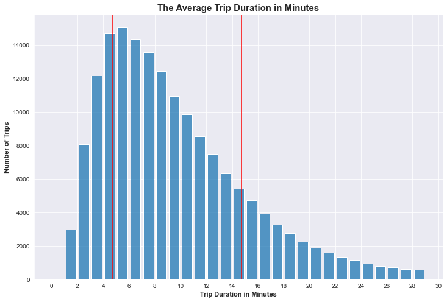

```python
#let's use histplot, set xticks till 30 minutes to more interpret
sb.set_style('darkgrid')
plt.figure(figsize=[12,8])
bins = np.arange(0, 30, 1)
ticks = np.arange(0, 32, 2)
labels = ['{}'.format(v) for v in ticks]
sb.histplot(data= fordbike_2019, x= 'duration_min', bins = bins, shrink=0.8)
plt.xticks(ticks, labels)
plt.title('The Average Trip Duration in Minutes', fontsize=15, fontweight='bold')
plt.xlabel('Trip Duration in Minutes', fontsize=11, fontweight='bold')
plt.ylabel('Number of Trips',fontsize=11, fontweight='bold')
plt.axvline(fordbike_2019.duration_min.mean()+3, color='r')
plt.axvline(fordbike_2019.duration_min.mean()-7, color='r');
```

we can easily interpret from the above plot, that a majority of users have a tendency towards using the bikes for a short-time duration trip.Most trips take between 4 to 15 minutes

#### When are most trips taken in weekdays?

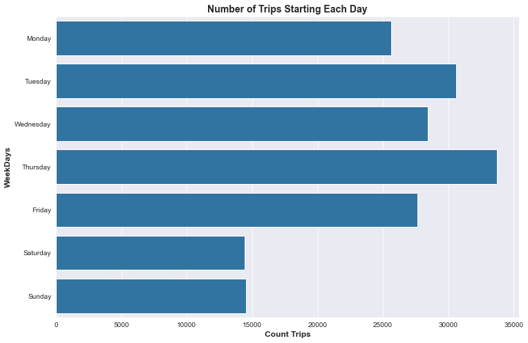

```python
#plot number of trips starting each day using countplot

sb.set_style('darkgrid')
base_color = sb.color_palette()[0]
day_ordered = ['Monday','Tuesday','Wednesday','Thursday',
            'Friday','Saturday','Sunday']
plt.figure(figsize=(12,8))
sb.countplot(data= fordbike_2019, y = 'start_day', color=base_color, order=day_ordered)
plt.title('Number of Trips Starting Each Day', fontweight='bold', fontsize=14)
plt.ylabel('WeekDays', fontweight='bold', fontsize=12)
plt.xlabel('Count Trips', fontweight='bold', fontsize=12);
```

From above figure we can see the most trips were taken on thursday while the least on saturday and sunday.

#### When are most trips taken in terms of time of day?

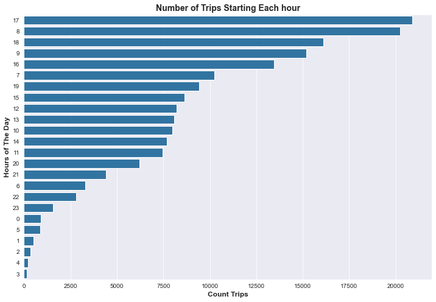

```python
#plot number of trips starting each hour using countplot
sb.set_style('darkgrid')
base_color = sb.color_palette()[0]
hour_ordered = fordbike_2019.start_hour.value_counts().index
plt.figure(figsize=(12,8))
sb.countplot(data= fordbike_2019, y = 'start_hour', color=base_color, order=hour_ordered)
plt.title('Number of Trips Starting Each hour', fontweight='bold', fontsize=14)
plt.ylabel('Hours of The Day', fontweight='bold', fontsize=12)
plt.xlabel('Count Trips', fontweight='bold', fontsize=12);
```

We can see from above figure the most trips were taken at 5 PM and 8 AM, while the number of trips decreases after midnight.

#### What is the most common type of bike share user? Is Male members more than females use the bike share?

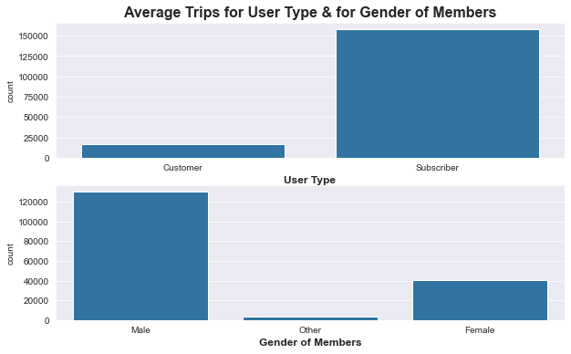

```python
#I will move on to the other features in the data : `user_type` ,  `member_gender`
fig, ax = plt.subplots(nrows=2, figsize=(10,6))
g = sb.countplot(data=fordbike_2019, x='user_type', color=base_color, ax= ax[0])
ax[0].set_xlabel('User Type', fontweight='bold', fontsize=12)
g.set_title('Average Trips for User Type & for Gender of Members', fontsize=16, fontweight='bold')
sb.countplot(data=fordbike_2019, x='member_gender', color=base_color, ax= ax[1])
ax[1].set_xlabel('Gender of Members', fontweight='bold', fontsize=12);
```

we noticed from previous figures the following :

- The Subscriber type is the most common.
- Male members more than females use the bike share.

#### What is the average of members age?

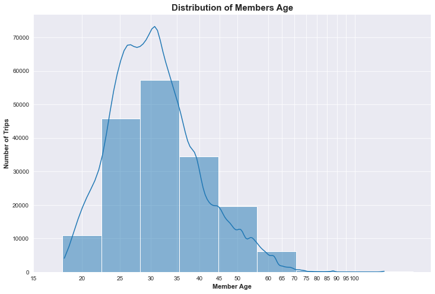

```python
#plot members age using histplot with kernal density estimation(kde), and use log scale
sb.set_style('darkgrid')
plt.figure(figsize=[12,8])
bins = 10 ** np.arange(1.25, np.log10(fordbike_2019.member_age.max())+0.1, 0.1)
ticks = [15, 20, 25, 30, 35, 40, 45, 50, 60, 65, 70, 75, 80, 85, 90, 95, 100]
labels = ['{}'.format(v) for v in ticks]
sb.histplot(data= fordbike_2019, x= 'member_age', bins=bins, kde=True)
plt.xscale('log')
plt.xticks(ticks, labels)
plt.title('Distribution of Members Age', fontsize=15, fontweight='bold')
plt.xlabel('Member Age', fontsize=11, fontweight='bold')
plt.ylabel('Number of Trips',fontsize=11, fontweight='bold');
```

According to previous figure, most members are around 25 to 45 years old.

### Of the features you investigated, were there any unusual distributions? Did you perform any operations on the data to tidy, adjust, or change the form of the data? If so, why did you do this?

From other plots, I observed that:

- The most trips were taken on thursday while the least on saturday and sunday.
- The Subscriber type is the most common type than Customer type.
- Male members more than females use the bike share.
- Most members are around 25 to 45 years old. I did the following:
- I created column for trip duration in minutes to easily interpret more than duration in seconds
- I created column for start day and start hour to figure out which day and hour is most trips taken, before do that I converted datatype of start time to datetime.
- I converted datatype of member_birth_year to int and fix the outlier, to creat column for member age.
- I converted datatype of user_type, member_gender to category to plot them.
- The member age plot has long-tailed distribution skewed to right, so I used scale transformation.

## Bivariate Exploration

- How long does the average trip take for each day of the week?
- How long is the trip in minutes per hour during the day?
- What is the trip duration in minutes according to the type of user, and the gender of members?
- Is there a relationship between the age of the member and the duration of the trip?
- When are most trips taken hourly during the day depending on the type of user?
- When are most trips taken for each day of the week depending on the type of user?
- Do male members use more bikes than females by user type?

#### How long does the average trip take for each day of the week?

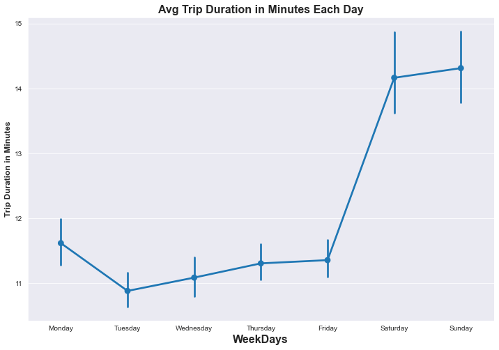

```python
#plot start_day and duration_min using pointplot
plt.figure(figsize=(12,8))
day_ordered = ['Monday','Tuesday','Wednesday','Thursday',
            'Friday','Saturday','Sunday']
sb.pointplot(data=fordbike_2019, x='start_day', y='duration_min',
             color=base_color, order = day_ordered)
plt.xlabel('WeekDays', fontsize=16, fontweight='bold')
plt.ylabel('Trip Duration in Minutes', fontsize=12, fontweight='bold')
plt.title('Avg Trip Duration in Minutes Each Day', fontsize=16, fontweight='bold');
```

From figure above, we observed that all week days have short trips, except weekend (saturday and sunday) has long trips.

#### How long is the trip in minutes per hour during the day?

[figure not shown]

```python
plt.figure(figsize=(12,8))

sb.barplot(data=fordbike_2019, x='start_hour', y='duration_min', color=base_color)
plt.xlabel('Hour', fontweight='bold', fontsize=12)
plt.ylabel('Trip Duration in Minutes', fontsize=12, fontweight='bold')
plt.title('Avg Trip Duration in Minutes Each Hour', fontsize=16, fontweight='bold');
```

I observed that most hours of the day have short trips except 2 am and 3 am have long trips.

#### What is the trip duration in minutes according to the type of user, and the gender of members?

```python
#set derution_min less than or equal to 60 minutes
duration_65 = fordbike_2019.query('duration_min<=60')
```

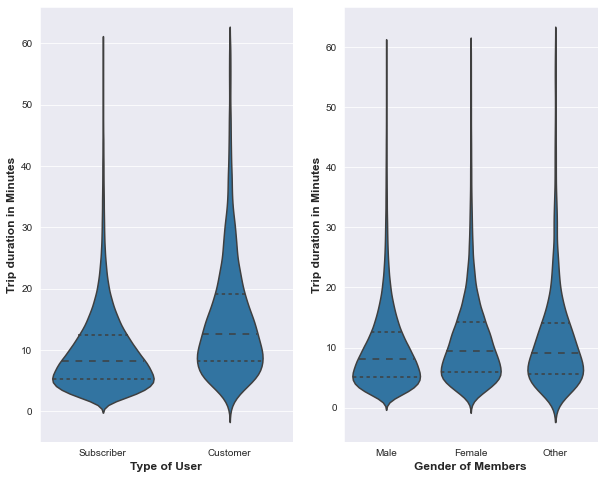

```python
#user_type, member_gender against duration_min using violinplot
fig, ax = plt.subplots(ncols=2, figsize=(10,8))
sb.violinplot(data=duration_65, x='user_type', y='duration_min', ax=ax[0], color=base_color, inner='quartile')
ax[0].set_xlabel('Type of User', fontsize=12, fontweight='bold')

ax[0].set_ylabel('Trip duration in Minutes', fontsize=12, fontweight='bold')

sb.violinplot(data=duration_65, x='member_gender', y='duration_min', ax=ax[1], color=base_color, inner='quartile')
ax[1].set_xlabel('Gender of Members', fontsize=12, fontweight='bold')
ax[1].set_ylabel('Trip duration in Minutes', fontsize=12, fontweight='bold');
```

We observed:

- The Customers use long trips more, while the Subscribers use shorts more.
- It seems that male and female members with same trip duration, no big difference between them.

#### Is there a relationship between the age of the member and the duration of the trip?

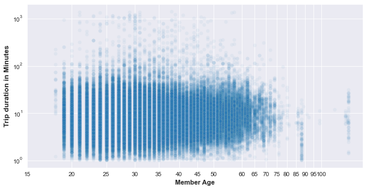

```python
plt.figure(figsize=(10,5))
bins = 10 ** np.arange(1.25, np.log10(fordbike_2019.member_age.max())+0.1, 0.1)
ticks = [15, 20, 25, 30, 35, 40, 45, 50, 60, 65, 70, 75, 80, 85, 90, 95, 100]
labels = ['{}'.format(v) for v in ticks]
sb.scatterplot(data=fordbike_2019, x='member_age', y='duration_min', x_bins=bins, alpha=1/20)
plt.xscale('log')
plt.xticks(ticks, labels)
plt.xlabel('Member Age', fontsize=11, fontweight='bold')
plt.ylabel('Trip duration in Minutes', fontsize=12, fontweight='bold')
plt.yscale('log');
```

#### When are most trips taken hourly during the day depending on the type of user?

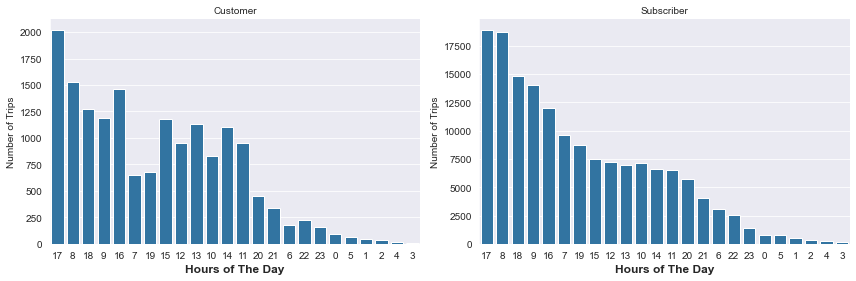

```python
g = sb.FacetGrid(data=fordbike_2019,col='user_type', col_wrap = 2, height = 4, aspect=1.5, sharey=False, margin_titles=True)
g.map_dataframe(sb.countplot, 'start_hour', order=fordbike_2019.start_hour.value_counts().index)
g.set_titles(col_template='{col_name}')
for i in range(2):
    g.axes[i].set_xlabel('Hours of The Day', fontsize=12, fontweight='bold')
    g.axes[i].set_ylabel('Number of Trips');
```

#### When are most trips taken for each day of the week depending on the type of user?

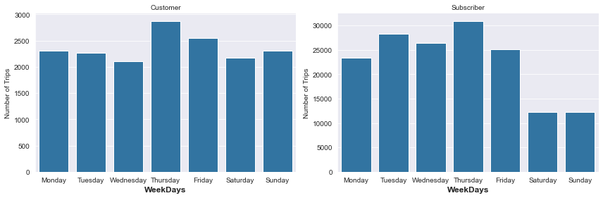

```python
g = sb.FacetGrid(data=fordbike_2019,col='user_type', col_wrap = 2, height = 4, aspect=1.5, sharey=False, margin_titles=True)
day_ordered = ['Monday','Tuesday','Wednesday','Thursday',
            'Friday','Saturday','Sunday']
g.map_dataframe(sb.countplot, 'start_day', order = day_ordered)
g.set_titles(col_template='{col_name}')
for i in range(2):
    g.axes[i].set_xlabel('WeekDays', fontsize=12, fontweight='bold')
    g.axes[i].set_ylabel('Number of Trips');
```

As before, There was much more subscriber usage than casual customers overall. We note that the subscriber has more bike trips most days of the week except on weekends (Saturday, Sunday), while customers have bike trips every day of the week including weekend (Saturday, Sunday).

#### Do male members use more bikes than females by user type?

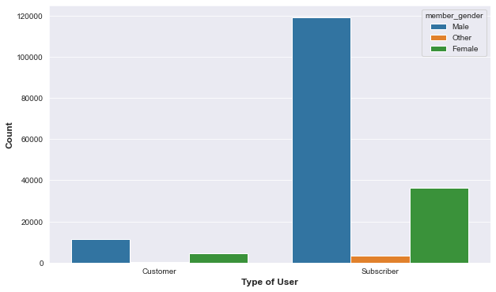

```python
plt.figure(figsize=(10,6))
sb.countplot(data=fordbike_2019, x='user_type', hue='member_gender')
plt.xlabel('Type of User', fontweight='bold', fontsize=12)

plt.ylabel('Count', fontweight='bold', fontsize=12);
```

The Male Subscriber more than female, and also the male Customer more than the Female.

## Multivariate Exploration

- How long does the average trip take for each day of the week depending on the type of user?
- When are most trips taken hourly during the day for each day depending on the type of user?
- When are most trips taken hourly during the day for each day depending on the type of user and the gender of member?

#### How long does the average trip take for each day of the week depending on the type of user?

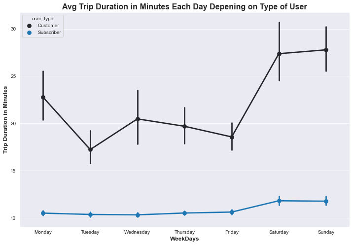

```python
plt.figure(figsize=(12,8))
day_ordered = ['Monday','Tuesday','Wednesday','Thursday',
            'Friday','Saturday','Sunday']
sb.pointplot(data=fordbike_2019, x='start_day', y='duration_min',
             color=base_color, order = day_ordered,
             hue='user_type')
plt.xlabel('WeekDays', fontsize=12, fontweight='bold')
plt.ylabel('Trip Duration in Minutes', fontsize=12, fontweight='bold')

plt.title('Avg Trip Duration in Minutes Each Day Depening on Type of User', fontsize=16, fontweight='bold');
```

From the chart above it appears that subscribers are riding much shorter rides compared to customers every day of the week. Both types of users have a clear increase in trip duration on Saturdays and Sundays during the weekends, especially for regular customers. The use of subscribers appears to be more efficient than clients in general and has maintained a very constant average duration from Monday to Friday.

#### When are most trips taken hourly during the day for each day depending on the type of user?

```python
day_ordered = ['Monday','Tuesday','Wednesday','Thursday',
            'Friday','Saturday','Sunday']
trip_sub = fordbike_2019.query('user_type == "Subscriber"').groupby(['start_day', 'start_hour']).size()
trip_sub = trip_sub.reset_index(name='count').pivot(index='start_day', columns='start_hour', values='count')
trip_sub = trip_sub.reindex(day_ordered)
trip_cus = fordbike_2019.query('user_type == "Customer"').groupby(['start_day', 'start_hour']).size()
trip_cus = trip_cus.reset_index(name='count').pivot(index= 'start_day', columns='start_hour', values='count')
trip_cus = trip_cus.reindex(day_ordered)
```

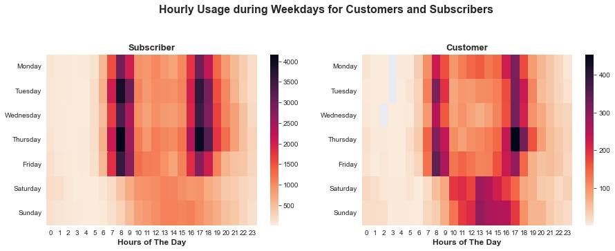

```python
plt.figure(figsize=(15,10))

plt.suptitle('Hourly Usage during Weekdays for Customers and Subscribers', fontsize=16, fontweight='bold')

plt.subplot(2,2,1)
sb.heatmap(trip_sub, cmap='rocket_r')
plt.xlabel('Hours of The Day', fontsize=12, fontweight='bold')
plt.ylabel('Weekdays')
plt.title('Subscriber', fontsize=13, fontweight='bold')
plt.ylabel('')


plt.subplot(2,2,2)
sb.heatmap(trip_cus, cmap='rocket_r')
plt.xlabel('Hours of The Day', fontsize=12, fontweight='bold')
plt.title('Customer', fontsize=13, fontweight='bold')
plt.ylabel('');
```

The previous Heatmaps clearly show a very different usage pattern of use between the two types of users:

- Subscribers use the system heavily on working days, ie from Monday to Friday.
- Customers use a bikeshare a lot on weekends(saturday,sunday), especially in the afternoon.
- For Subscriber Most trips concentrate around 7-9 a.m. and 4-6 p.m.

[figure not shown]

```python
day_ordered = ['Monday','Tuesday','Wednesday','Thursday',
            'Friday','Saturday','Sunday']
g = sb.FacetGrid(data=fordbike_2019,col='user_type', height = 4, aspect=1.5, sharey=False, margin_titles=True)
g.map_dataframe(sb.countplot, 'start_day', order=day_ordered, hue='member_gender')
g.set_titles(col_template='{col_name}')
g.add_legend();
```

I observed from previous plot:

- For customer and subscriber user the male user for both has more trips than female.

### Talk about some of the relationships you observed in this part of the investigation. Were there features that strengthened each other in terms of looking at your feature(s) of interest?

Multivariate exploration reinforced some of the patterns detected in previous bivariate as well as univariate exploration.

- The relation between the trip duration and weekdays depending on type of user:  
  It appears that subscribers are riding much shorter rides compared to customers every day of the week. Both types of users have a clear increase in trip duration on Saturdays and Sundays during the weekends, especially for regular customers. The use of subscribers appears to be more efficient than clients in general and has maintained a very constant average duration from Monday to Friday.
- The relation between hours of day and weekdays and the number of trips depending on the type of user:  
  Subscribers use the system heavily on working days, ie from Monday to Friday. Customers use a bikeshare a lot on weekends(saturday,sunday), especially in the afternoon. For Subscriber Most trips concentrate around 7-9 a.m. and 4-6 p.m.
- For customer and subscriber user the male user for both has more trips than female.

### Were there any interesting or surprising interactions between features?

I think there is no big surprise observed here. all the interactions between the features complement each other and make perfect sense.